# Re-selling MC Goods

Matthias Fuchs

October 3rd, 2019

# Data description

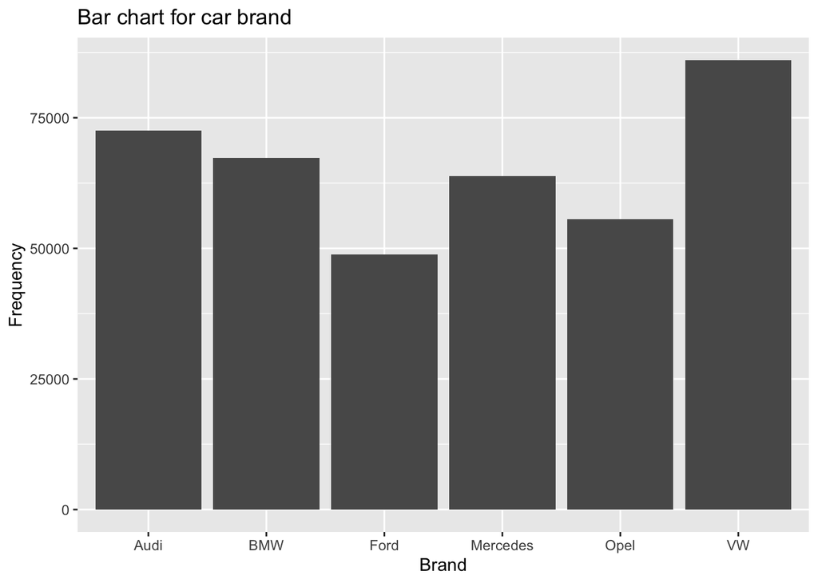

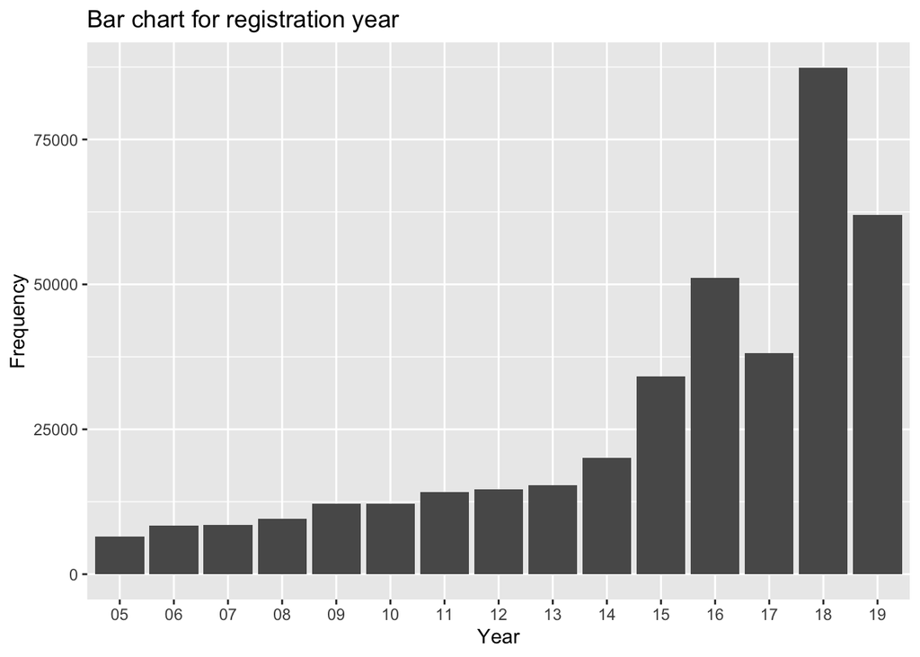

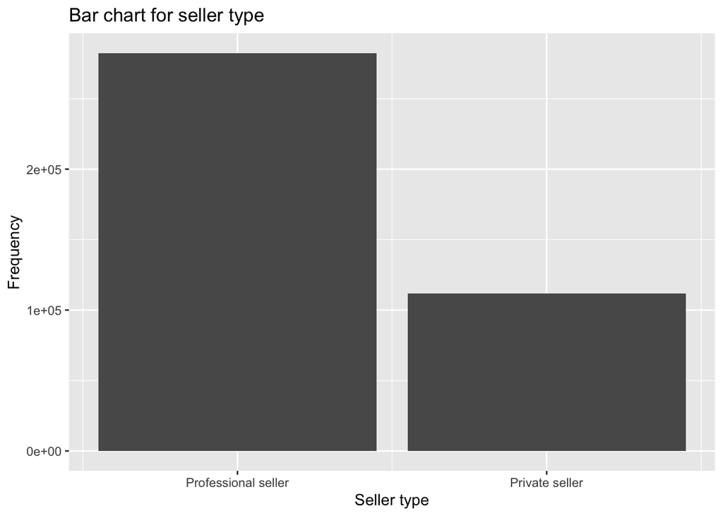

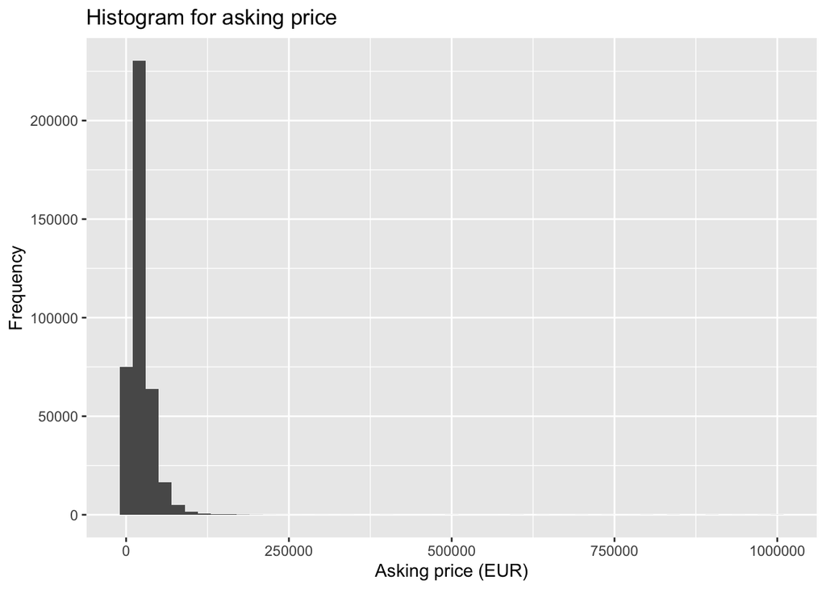

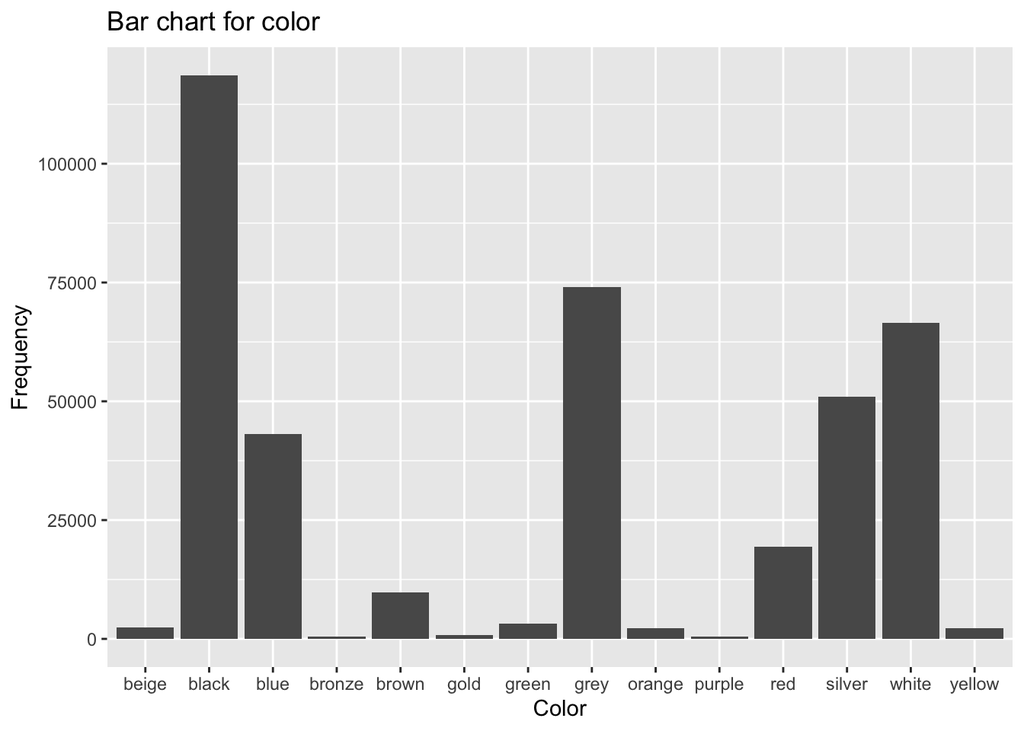

# Looking at color popularity by the year of first registration and by model (ColPopPyPm)

I was inspired to run this analysis after reading this article: https://www.whatcar.com/news/what-are-the-best-car-colours-for-resale-value/n18356.

Average holding duration of cars is 5.6 years in Germany (Focus Online, 2012) and around 8.68 years for new cars (DAT Report, 2016)

### Regressions with the DV Price

*Dependent variable:*

Price

(1)

(2)

(3)

(4)

colpopPYPM

7,251.703***

9,553.518***

25,562.810***

28,110.250***

(392.368)

(470.757)

(705.426)

(948.846)

privateseller

499.680***

2,799.336***

1,515.622***

4,428.523***

(107.440)

(182.129)

(124.346)

(446.281)

sport

1,650.785***

2,729.079***

2,736.680***

2,683.827***

(75.154)

(100.905)

(100.739)

(100.974)

individual

-6,424.554***

-2,747.553***

-2,621.293***

-2,676.834***

(422.520)

(648.914)

(648.159)

(648.143)

Power

95.914***

75.837***

75.260***

75.356***

(1.204)

(1.385)

(1.384)

(1.384)

sqrt(Mileage)

-41.857***

-26.847***

-26.818***

-26.804***

(0.556)

(0.589)

(0.588)

(0.588)

sqrt(ageindays)

-436.812***

-268.661***

-148.091***

-137.697***

(4.530)

(4.492)

(5.849)

(6.913)

TransmissionHalbautomatik

-771.655

-1,813.835

-1,792.760

-1,760.523

(1,637.103)

(1,401.707)

(1,400.096)

(1,400.005)

TransmissionSchaltgetriebe

-378.003***

-1,794.491***

-1,783.295***

-1,764.800***

(89.501)

(95.353)

(95.244)

(95.320)

hud

4,003.964***

4,233.546***

4,083.393***

3,984.920***

(193.288)

(202.895)

(202.725)

(203.616)

acc

490.656**

380.026*

537.881**

584.530***

(157.570)

(166.039)

(165.923)

(166.226)

glasdach

440.938*

270.250

267.677

270.437

(187.228)

(230.526)

(230.262)

(230.244)

laser

22,833.580***

10,500.270***

9,987.397***

9,876.228***

(1,087.104)

(860.889)

(860.065)

(860.562)

led

-1,012.843***

834.549***

845.867***

836.964***

(84.167)

(110.346)

(110.215)

(110.248)

leather

330.127*

-776.036***

-715.535***

-740.910***

(128.565)

(150.835)

(150.653)

(150.699)

navi

-1,750.724***

-1,191.364***

-1,178.665***

-1,181.038***

(72.290)

(81.388)

(81.296)

(81.307)

standheizung

-95.817

749.591*

738.141*

738.628*

(277.093)

(351.798)

(351.395)

(351.370)

brandBMW

-5,977.386

-6,395.440

-6,332.120

(6,228.558)

(6,209.378)

(6,197.146)

brandFord

-11,021.080

-10,946.910

-10,922.220

(8,988.832)

(8,961.295)

(8,943.115)

brandMercedes

10,251.290

6,630.490

7,457.213

7,359.511

(8,309.535)

(5,946.695)

(5,928.529)

(5,916.586)

brandOpel

-14,281.300

-14,206.770

-14,123.660

(9,902.627)

(9,872.270)

(9,852.230)

brandVW

-11,406.270

-11,302.380

-11,228.460

(8,066.256)

(8,041.561)

(8,025.286)

colpopPYPM:privateseller

-5,312.675***

-7,056.722***

(563.763)

(1,362.692)

sqrt(ageindays):privateseller

-49.428***

(9.854)

colpopPYPM:sqrt(ageindays):privateseller

95.497**

(31.992)

colpopPYPM:sqrt(ageindays)

-492.938***

-518.335***

(15.770)

(22.163)

Constant

43,079.280***

38,018.440***

34,037.700***

33,316.070***

(7,547.823)

(5,625.832)

(5,598.678)

(5,591.044)

Observations

128,453

386,693

386,693

386,693

Log Likelihood

-1,381,806.000

-4,410,009.000

-4,409,569.000

-4,409,522.000

Akaike Inf. Crit.

2,763,659.000

8,820,075.000

8,819,195.000

8,819,106.000

Bayesian Inf. Crit.

2,763,893.000

8,820,379.000

8,819,499.000

8,819,443.000

*Note:*

- p<0.05; ** p<0.01; *** p<0.001

### Regressions with the DV Age or Mileage

*Dependent variable:*

ageindays

Mileage

(1)

(2)

(3)

(4)

colpopPYPM

534.439***

858.302***

964.686

2,039.957

(11.931)

(15.027)

(1,203.654)

(1,522.727)

privateseller

499.957***

648.176***

8,793.518***

9,291.220***

(4.563)

(6.193)

(470.341)

(638.499)

sport

14.140***

10.682***

600.172

588.911

(3.166)

(3.161)

(320.712)

(320.860)

individual

-17.674

-23.011

1,120.911

1,101.899

(20.359)

(20.317)

(2,062.648)

(2,062.711)

Power

0.305***

0.318***

90.027***

90.053***

(0.046)

(0.046)

(4.082)

(4.082)

sqrt(Mileage)

5.409***

5.385***

(0.014)

(0.014)

sqrt(ageindays)

2,145.752***

2,144.654***

(11.897)

(11.935)

sqrt(Price)

-8.606***

-8.594***

-351.034***

-351.138***

(0.045)

(0.045)

(4.681)

(4.682)

TransmissionHalbautomatik

293.542***

296.463***

-8,301.674

-8,287.798

(45.138)

(45.044)

(4,590.748)

(4,590.761)

TransmissionSchaltgetriebe

59.372***

58.704***

-1,896.785***

-1,898.776***

(3.034)

(3.028)

(306.851)

(306.855)

hud

-71.026***

-72.451***

-1,737.159**

-1,741.819**

(6.092)

(6.079)

(617.673)

(617.686)

acc

-90.364***

-90.523***

-220.684

-222.796

(4.846)

(4.836)

(493.090)

(493.094)

glasdach

25.569***

26.315***

-489.982

-486.523

(7.124)

(7.109)

(724.249)

(724.255)

laser

-64.188**

-66.900**

2,236.614

2,233.863

(24.886)

(24.834)

(2,499.222)

(2,499.211)

led

-93.286***

-93.912***

-954.119**

-957.553**

(3.235)

(3.228)

(329.246)

(329.259)

leather

108.307***

105.980***

1,616.979**

1,610.935**

(4.845)

(4.836)

(492.962)

(492.990)

navi

-183.849***

-182.731***

26.603

28.628

(2.486)

(2.481)

(253.519)

(253.525)

standheizung

82.511***

83.722***

-2,970.181**

-2,963.983**

(11.015)

(10.992)

(1,119.761)

(1,119.773)

brandBMW

-397.794**

-348.172*

-7,708.347**

-7,574.429**

(136.543)

(135.175)

(2,782.398)

(2,784.251)

brandFord

-581.358**

-579.124**

-12,224.600**

-12,210.020**

(196.479)

(194.492)

(3,890.206)

(3,889.389)

brandMercedes

280.908*

258.864*

3,925.806

3,881.703

(130.382)

(129.071)

(2,637.750)

(2,637.478)

brandOpel

-754.293***

-741.208***

-12,804.070**

-12,778.600**

(216.304)

(214.113)

(4,223.380)

(4,222.512)

brandVW

-459.816**

-442.025*

-6,878.864

-6,845.751

(176.615)

(174.836)

(3,548.247)

(3,547.603)

colpopPYPM:privateseller

-645.566***

-2,140.568

(18.279)

(1,857.187)

Constant

2,073.916***

2,000.552***

29,274.150***

29,093.730***

(152.148)

(151.208)

(5,456.772)

(5,458.629)

Observations

297,353

297,353

297,353

297,353

Log Likelihood

-2,322,752.000

-2,322,126.000

-3,696,580.000

-3,696,571.000

Akaike Inf. Crit.

4,645,558.000

4,644,308.000

7,393,215.000

7,393,199.000

Bayesian Inf. Crit.

4,645,844.000

4,644,605.000

7,393,501.000

7,393,495.000

*Note:*

- p<0.05; ** p<0.01; *** p<0.001

Random effects on intercept: Car Color, Car Model, Car Fuel Type

### Partial Effects Plot PrivateSeller x ColPopPyPm on Price

```
## NOTE: privatesellercolpopPYPM does not appear in the model
```

```
## NOTE: privatesellercolpopPYPM is not a high-order term in the model
```

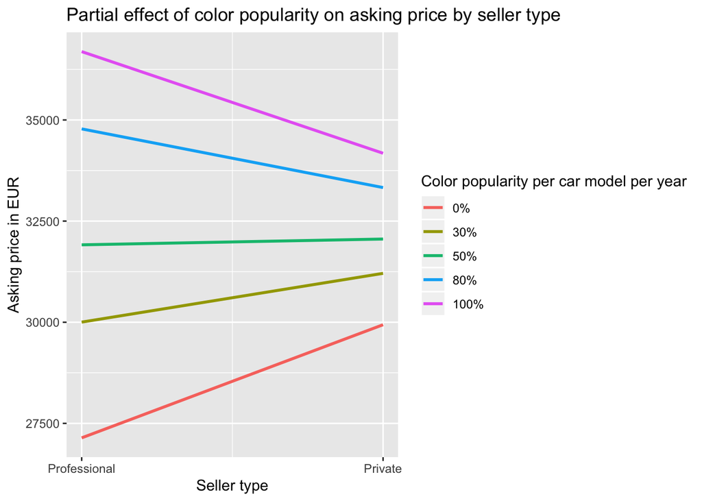

### Partial Effects Plot Age x ColPopPyPm on Price

```
## NOTE: sqrt(ageindays)colpopPYPM is not a high-order term in the model
```

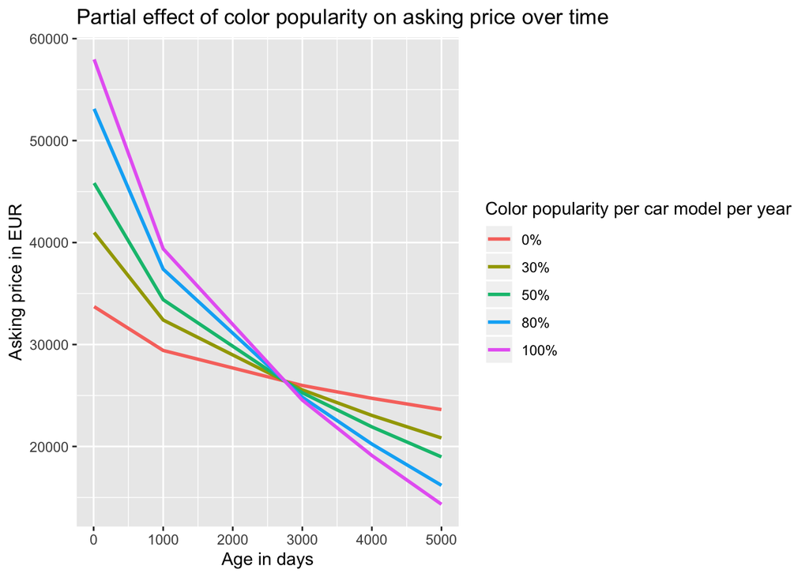

### Partial Effects Plot PrivateSeller x ColPopPyPm x Age on Price

```
## NOTE: privatesellercolpopPYPMsqrt(ageindays) is not a high-order term in the model
```

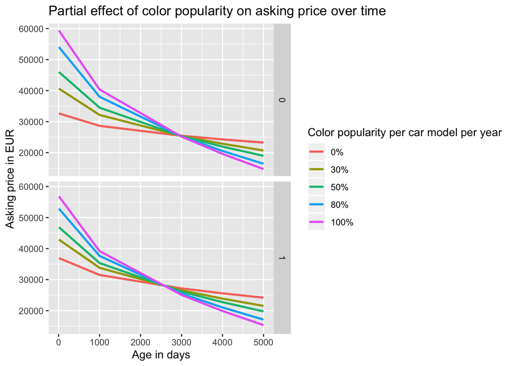

### Partial Effects Plot PrivateSeller x ColPopPyPm on Age

```
## NOTE: privatesellercolpopPYPM does not appear in the model
```

```
## NOTE: privatesellercolpopPYPM is not a high-order term in the model
```

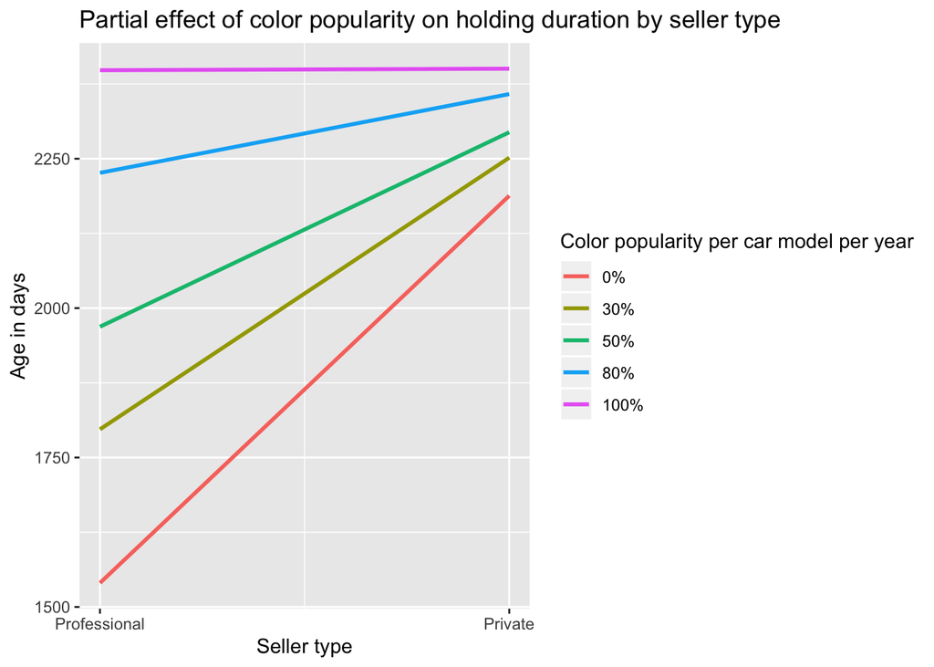

### Partial Effects Plot PrivateSeller x ColPopPyPm on Mileage

```
## NOTE: privatesellercolpopPYPM does not appear in the model
```

```
## NOTE: privatesellercolpopPYPM is not a high-order term in the model
```

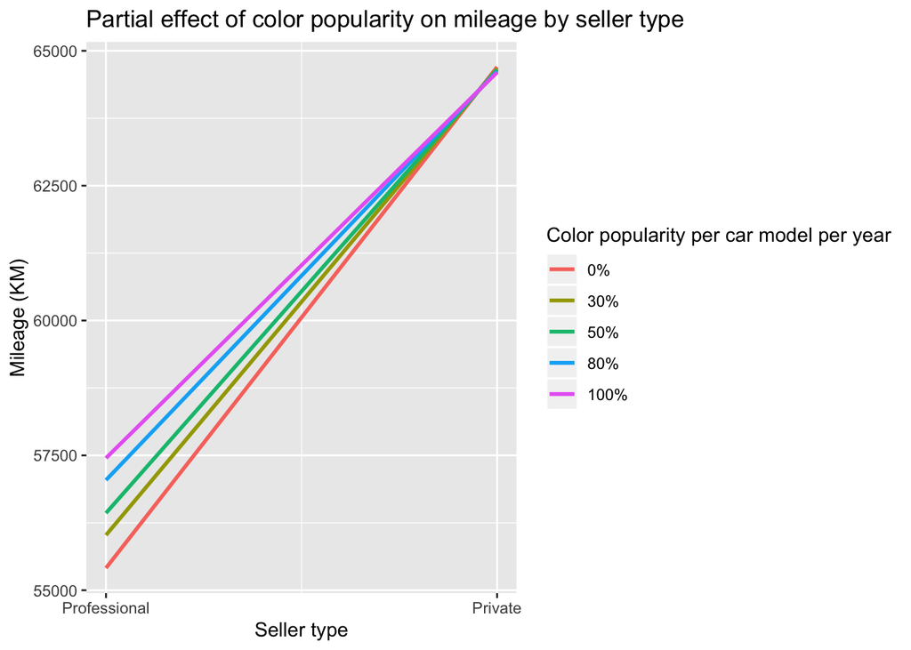

# Looking at the individual package for premium car brands (Individual; BMW, Audi & Mercedes only)

### Regressions with the DV Price

*Dependent variable:*

Price

(1)

(2)

(3)

(4)

sport

1,762.990***

1,764.196***

1,770.065***

1,769.365***

(65.535)

(65.526)

(65.523)

(65.508)

individual

-3,061.988***

-5,162.532***

3,800.517***

8,424.172***

(363.309)

(453.589)

(758.489)

(915.779)

privateseller

48.268

25.180

33.577

25.500

(102.379)

(102.407)

(102.362)

(102.344)

Power

94.191***

94.184***

94.060***

94.042***

(1.095)

(1.094)

(1.095)

(1.095)

sqrt(Mileage)

-36.947***

-36.930***

-36.742***

-36.942***

(0.452)

(0.451)

(0.452)

(0.451)

sqrt(ageindays)

-452.017***

-451.977***

-452.227***

-450.239***

(3.550)

(3.549)

(3.550)

(3.552)

hud

2,245.647***

2,260.206***

2,242.496***

2,235.965***

(119.641)

(119.637)

(119.610)

(119.587)

acc

690.251***

687.346***

690.533***

688.070***

(152.618)

(152.595)

(152.578)

(152.548)

glasdach

160.508

158.381

162.683

169.959

(158.321)

(158.298)

(158.280)

(158.249)

laser

7,521.631***

7,577.620***

7,487.423***

7,489.667***

(483.119)

(483.100)

(483.003)

(482.899)

led

-1,462.075***

-1,466.962***

-1,451.788***

-1,446.300***

(76.224)

(76.215)

(76.212)

(76.200)

leather

79.948

82.409

76.799

75.185

(102.704)

(102.689)

(102.678)

(102.657)

navi

-2,147.404***

-2,148.900***

-2,149.120***

-2,145.572***

(62.185)

(62.176)

(62.169)

(62.156)

standheizung

364.297

356.613

350.424

344.676

(252.703)

(252.667)

(252.640)

(252.588)

brandBMW

-2,847.440

-2,897.942

-2,846.514

-2,851.372

(6,582.037)

(6,591.906)

(6,571.479)

(6,575.735)

brandMercedes

8,996.314

9,033.412

8,961.141

8,957.498

(6,281.633)

(6,291.048)

(6,271.561)

(6,275.621)

individual:privateseller

5,833.150***

(754.365)

individual:sqrt(Mileage)

-30.957***

(3.004)

individual:sqrt(ageindays)

-317.210***

(23.218)

Constant

43,240.100***

43,246.120***

43,237.900***

43,225.200***

(5,861.668)

(5,869.801)

(5,853.577)

(5,856.988)

Observations

197,601

197,601

197,601

197,601

Log Likelihood

-2,139,186.000

-2,139,148.000

-2,139,130.000

-2,139,088.000

Akaike Inf. Crit.

4,278,415.000

4,278,342.000

4,278,307.000

4,278,222.000

Bayesian Inf. Crit.

4,278,639.000

4,278,577.000

4,278,541.000

4,278,457.000

*Note:*

- p<0.05; ** p<0.01; *** p<0.001

### Regressions with the DV Age or Mileage

*Dependent variable:*

Mileage

ageindays

(1)

(2)

sport

2,420.181***

49.179***

(394.458)

(3.299)

individual

427.117

-39.796

(2,692.039)

(22.496)

privateseller

6,935.101***

348.696***

(748.805)

(6.195)

Power

169.256***

2.271***

(6.469)

(0.060)

sqrt(Price)

-672.654***

-17.471***

(9.511)

(0.073)

sqrt(ageindays)

1,558.868***

(24.756)

sqrt(Mileage)

2.718***

(0.023)

hud

114.527

-29.973***

(694.961)

(5.805)

acc

732.959

-19.734**

(878.791)

(7.332)

glasdach

59.345

8.686

(949.840)

(7.922)

laser

5,552.536*

18.630

(2,678.321)

(22.449)

led

-1,602.065***

-144.936***

(435.184)

(3.603)

leather

1,504.756*

95.088***

(643.181)

(5.356)

navi

-2,693.055***

-210.564***

(375.590)

(3.113)

standheizung

-1,581.855

25.299*

(1,521.939)

(12.695)

brandBMW

-8,988.923

-271.220

(4,822.994)

(210.046)

brandMercedes

5,883.410

440.301*

(4,577.087)

(200.516)

individual:privateseller

714.456

50.268

(4,634.061)

(38.695)

Constant

101,079.300***

3,938.650***

(8,231.719)

(214.604)

Observations

148,339

148,339

Log Likelihood

-1,853,011.000

-1,143,377.000

Akaike Inf. Crit.

3,706,067.000

2,286,799.000

Bayesian Inf. Crit.

3,706,295.000

2,287,027.000

*Note:*

- p<0.05; ** p<0.01; *** p<0.001

### Partial Effects Plot PrivateSeller x Individual on Price

```
## NOTE: privatesellerindividual is not a high-order term in the model
```

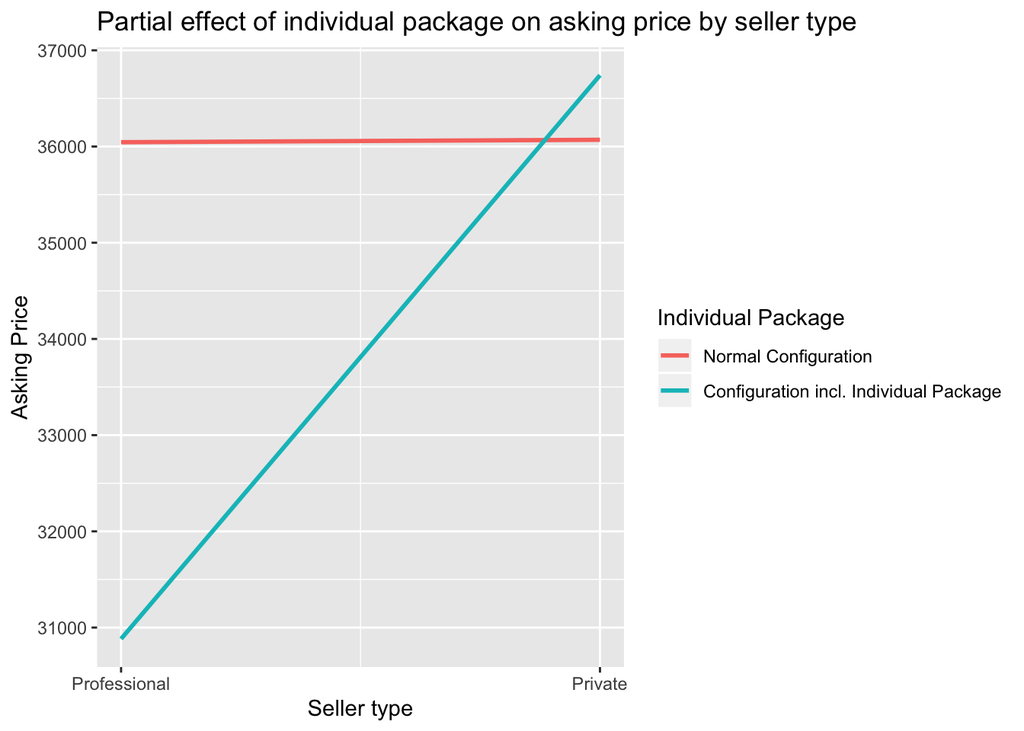

### Partial Effects Plot Mileage x Individual on Price

```
## NOTE: sqrt(Mileage)individual is not a high-order term in the model
```

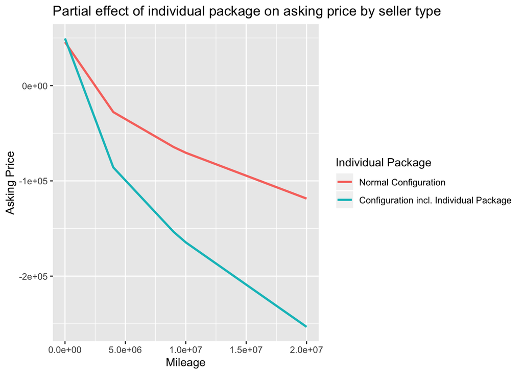

### Partial Effects Plot Age x Individual on Price

```
## NOTE: sqrt(ageindays)individual does not appear in the model
```

```
## NOTE: sqrt(ageindays)individual is not a high-order term in the model
```

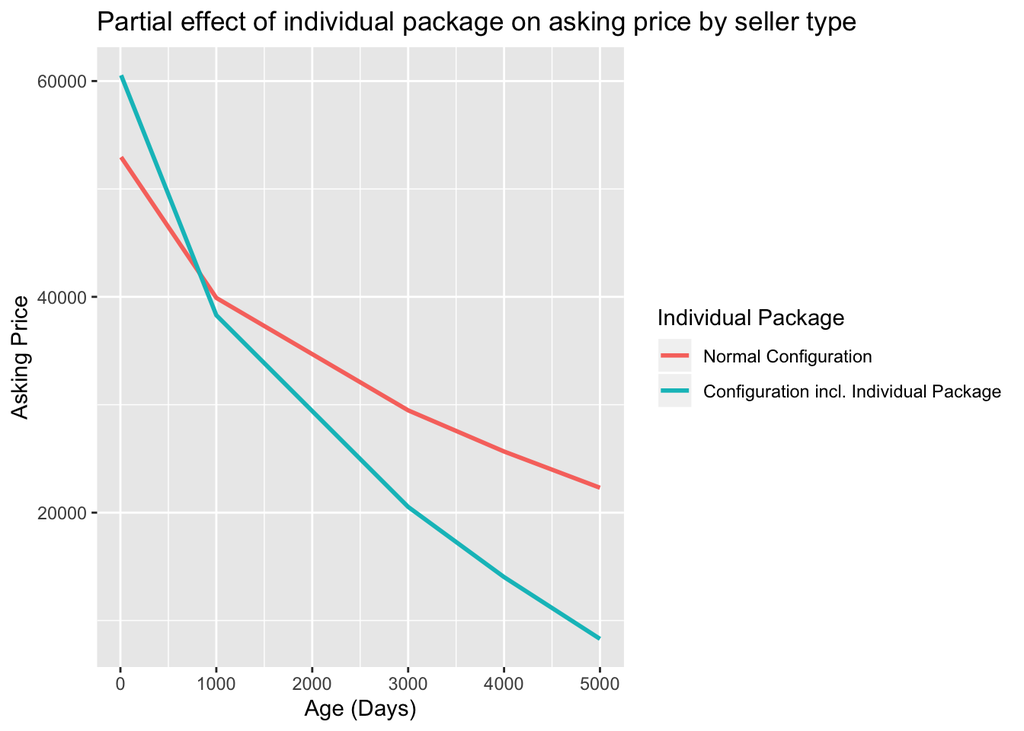

### Partial Effects Plot Age x Individual on Price

```
## NOTE: sqrt(ageindays)individual does not appear in the model
```

```
## NOTE: sqrt(ageindays)individual is not a high-order term in the model
```

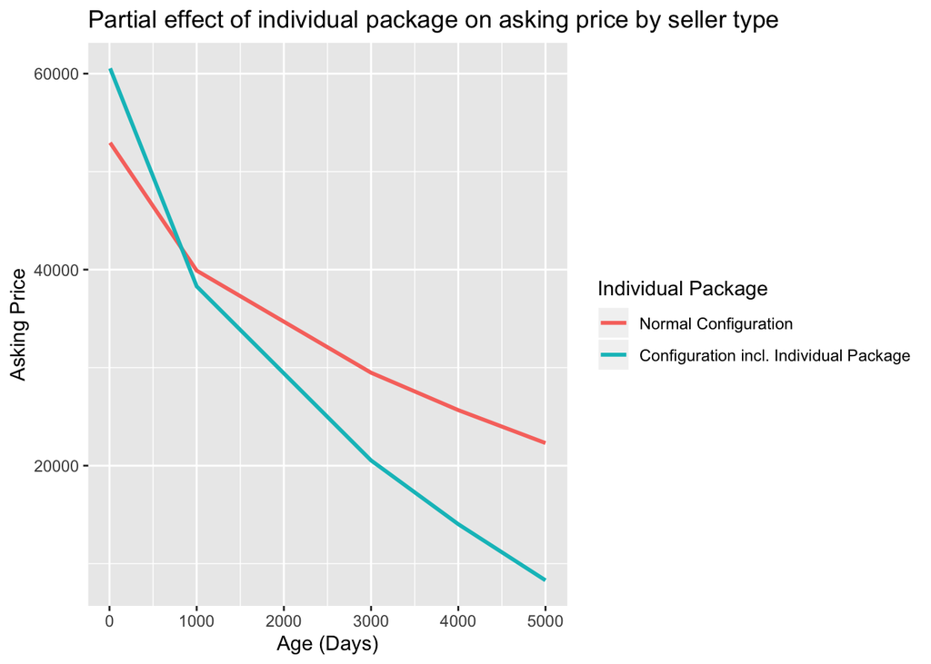